# Analysis of Fares and Operational Efficiency

We begin by pulling in fare data and specifying major airlines to analyze.

|  | quarter | airline_id | origin_airport | destination_airport | distance | X10 | X20 | X30 | X40 | X50 | X60 | X70 | X80 | X90 | X100 | X110 | X120 | X130 | X140 | X150 | X160 | X170 | X180 | X190 | X200 | X210 | X220 | X230 | X240 | … |
| --- | --- | --- | --- | --- | --- | --- | --- | --- | --- | --- | --- | --- | --- | --- | --- | --- | --- | --- | --- | --- | --- | --- | --- | --- | --- | --- | --- | --- | --- | --- |
| 1 | 1 | AA | CLT | SGF | 708 | 2 | 6 | 11 | 15 | 32 | 34 | 43 | 47 | 38 | 40 | 26 | 26 | 19 | 19 | 16 | 25 | 18 | 14 | 18 | 13 | 14 | 7 | 13 | 19 | … |

Right now, we don’t have actual average fare data for the flight - we have the number of people who paid within a bucket (of size 10). We need to convert this to an average fare paid, per quarter, per route.

|  | airline_id | origin_airport | destination_airport | quarter | avg_fare |
| --- | --- | --- | --- | --- | --- |
| 1 | AA | CLT | SGF | 1 | 166.22750 |
| 2 | DL | DTW | SAN | 1 | 471.55466 |
| 3 | DL | MSP | ISN | 1 | 130.69024 |
| 4 | AA | CLT | RDU | 1 | 32.28124 |
| 5 | DL | ATL | RIC | 1 | 114.96981 |

Now that we have the average fare in USD paid per route in each quarter, we can aggregate this across quarters and split the data to look at fares by airline and route.

| airline_id | route | origin_airport | distance | avg_fare |
| --- | --- | --- | --- | --- |
| AA | ABE CLE | ABE | 339 | 63.33333 |
| AA | ABE CLT | ABE | 481 | 123.32242 |
| AA | ABE PHL | ABE | 55 | 22.21275 |
| AA | ABI DFW | ABI | 158 | 40.20488 |
| AA | ABQ ATL | ABQ | 1269 | 115.00000 |

The question we want to examine is: Holding the airline and route distance constant, do higher delays caused at airports correlate with lower fares at that airport?

```r
#dataset created separately to group airlines with delays
delays <- read.csv('Data/delays.csv')

#Join route delays to fare information
route_fares_delays <- inner_join(route_fares, delays, by = 'origin_airport') %>%
  mutate(route_dist = cut(distance, breaks=seq(0,1500, by=100)))

#Filter to a specific airline for analysis
airline_filter <- "DL"

route_dist_by_airline <- route_fares_delays %>%
  group_by(airline_id, route_dist, origin_airport) %>%
  summarize(avg_fare_airport = mean(avg_fare), avg_delay_airport = mean(Avg..Total.Departure.Delay)) %>%
  filter(airline_id == "DL")

#hold distance constant, plot a scatterplot for each distance segment
unique_route <- unique(route_dist_by_airline$route_dist)

for(route in unique_route)
{
  selected_route <- filter(route_dist_by_airline, route_dist == route)

  plot(selected_route$avg_delay_airport, selected_route$avg_fare_airport, sub = paste("Flight Distance Between: ", route), main = paste(airline_filter, "Flights"), xlab="Delay (minutes)", ylab="Fare (USD $)")

  abline(lm(selected_route$avg_fare_airport ~ selected_route$avg_delay_airport))
}
```

[output not shown]

```r
airline_delay_by_airport <- flight_data %>%
  mutate(route = paste(origin_airport, destination_airport)) %>%
  group_by(airline_id, route) %>%
  summarize(delay (minutes) = mean(airline_delay))
```

```
Error: unexpected '=' in:
"  group_by(airline_id, route) %>%
  summarize(delay (minutes) ="
```

| airline_id | route | delay_minutes | origin_airport | distance | avg_fare |
| --- | --- | --- | --- | --- | --- |
| AA | ABQ DFW | 0.7166667 | ABQ | 569 | 148.0924 |

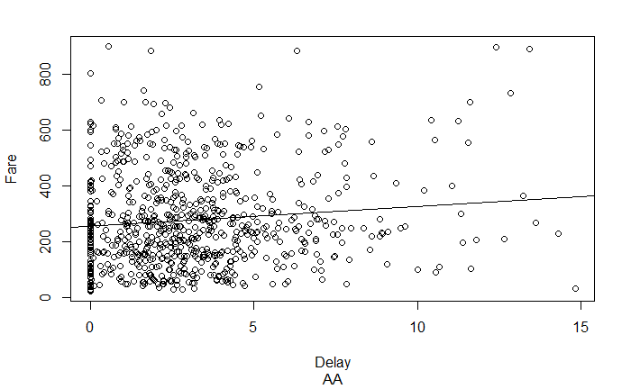

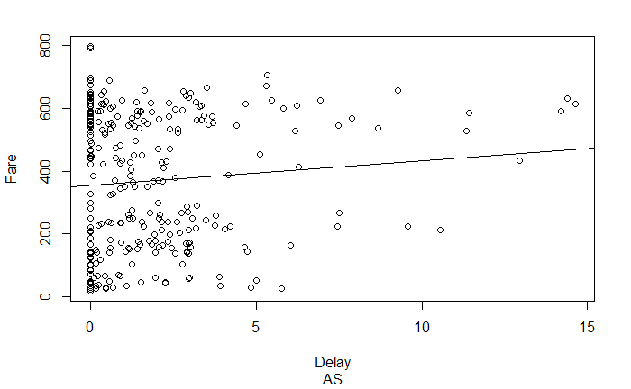

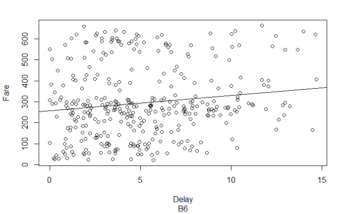

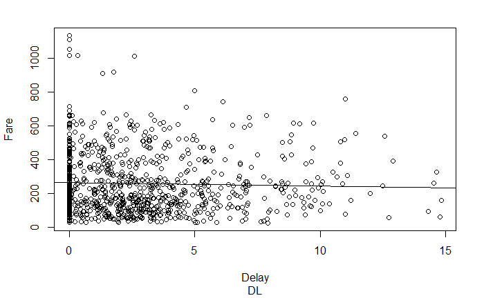

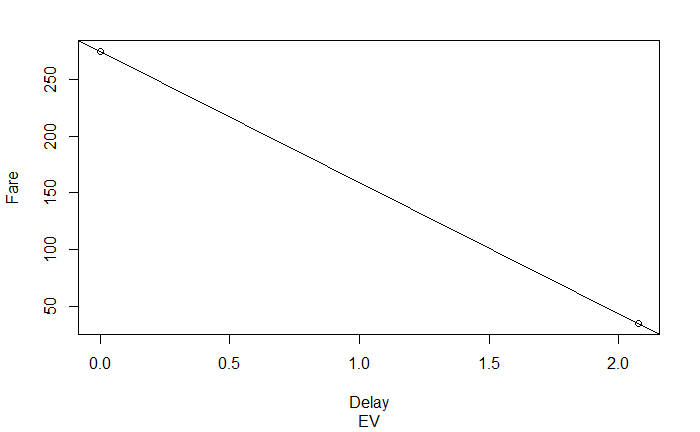

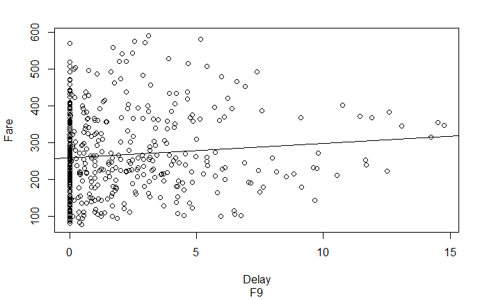

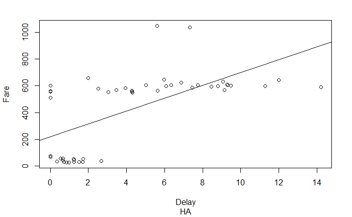

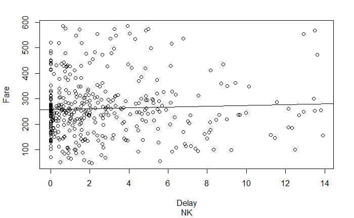

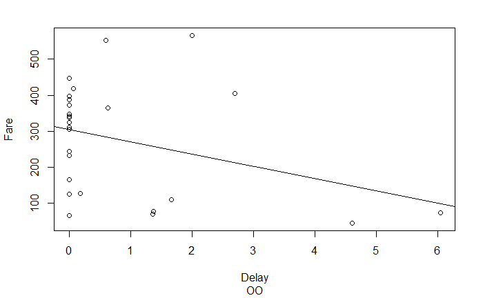

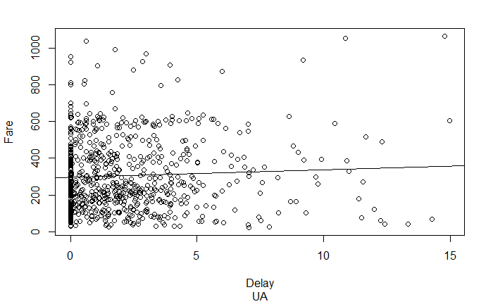

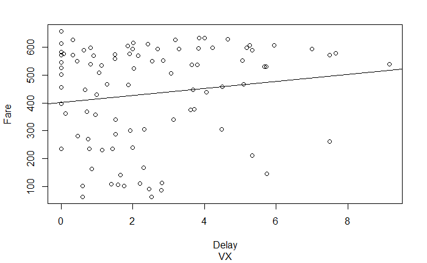

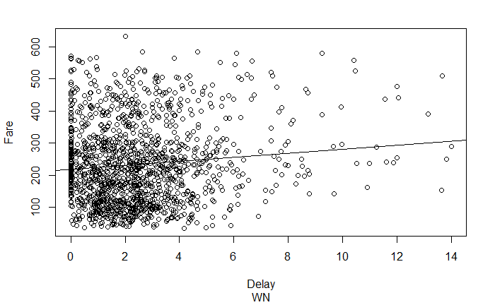